# M07-2-Application Assignment for R Data Types

Author

Allen Cosme

Published

March 22, 2026

# 1 Vectors

## 1.1 Create a numeric vector called “stock_prices” with the following data points: 42.5, 43.0, 44.1, and 2.7. Next, verify the class of it.

````markdown
```{r}
# Create a numeric vector of stock prices
stock_prices <- c(42.5, 43.0, 44.1, 2.7)

# Print the vector to confirm it was created correctly
stock_prices

# Verify the class of the vector
class(stock_prices)
```
````

```
[1] 42.5 43.0 44.1  2.7
[1] "numeric"
```

````markdown
```{r}
# Create a character vector of company names
stock_company <- c("Microsoft", "Apple", "Facebook", "Tesla")

# Print the vector to confirm it was created correctly
stock_company
```
````

```
[1] "Microsoft" "Apple"     "Facebook"  "Tesla"
```

## 1.3 Create a character vector called “stock_ticker” consisting of stock tickers corresponding to the companies in the “stock_company” vector: MSFT, AAPL, FB, and TSLA. Then verify its data type.

````markdown
```{r}
# Create a character vector of stock tickers
stock_ticker <- c("MSFT", "AAPL", "FB", "TSLA")

# Print the vector to confirm it was created correctly
stock_ticker

# Verify the data type / class
class(stock_ticker)
```
````

```
[1] "MSFT" "AAPL" "FB"   "TSLA"
[1] "character"
```

## 1.4 Create a logical vector called “make_cars” consisting of the four logical values: FALSE, FALSE, FALSE, and TRUE.

````markdown
```{r}
# Create a logical vector showing whether each company makes cars
make_cars <- c(FALSE, FALSE, FALSE, TRUE)

# Print the vector to confirm it was created correctly
make_cars

# Verify the class
class(make_cars)
```
````

```
[1] FALSE FALSE FALSE  TRUE
[1] "logical"
```

## 1.5 After that, add 5 to the vector “stock_prices” and assign the result to the same “stock_prices” vector, essentially updating the existing stock prices vector.

````markdown
```{r}
# Add 5 to each element in the stock_prices vector and update it
stock_prices <- stock_prices + 5
# Print the updated stock_prices vector to confirm the changes
stock_prices
```
````

```
[1] 47.5 48.0 49.1  7.7
```

## 1.6 Name each element in “stock_prices” vector, using the “stock_company” vector that you created above, and print the stock_prirces vector to confirm that each element has a company name associated with it.

````markdown
```{r}
# Assign company names to the stock_prices vector
names(stock_prices) <- stock_company

# Print the named vector to confirm the names were assigned
stock_prices
```
````

```
Microsoft     Apple  Facebook     Tesla
     47.5      48.0      49.1       7.7
```

# 2 Creating and cleaning a data frame in base R

## 2.1 Create a data frame called “stock_info.df” which is composed of the four vectors created in exercises #2 and #3 above. Verify the number of rows and columns, and also display the summary.

````markdown
```{r}
# Create a data frame using the four vectors created earlier
stock_info.df <- data.frame(
  stock_company = stock_company,
  stock_ticker = stock_ticker,
  stock_prices = stock_prices,
  make_cars = make_cars
)

# Print the data frame to confirm it was created correctly
stock_info.df

# Verify the number of rows and columns
nrow(stock_info.df)
ncol(stock_info.df)

# Display the summary of the data frame
summary(stock_info.df)
```
````

|  | stock_company | stock_ticker | stock_prices | make_cars |
| --- | --- | --- | --- | --- |
| Microsoft | Microsoft | MSFT | 47.5 | FALSE |
| Apple | Apple | AAPL | 48.0 | FALSE |
| Facebook | Facebook | FB | 49.1 | FALSE |
| Tesla | Tesla | TSLA | 7.7 | TRUE |

```
[1] 4
[1] 4
 stock_company      stock_ticker        stock_prices   make_cars
 Length:4           Length:4           Min.   : 7.70   Mode :logical
 Class :character   Class :character   1st Qu.:37.55   FALSE:3
 Mode  :character   Mode  :character   Median :47.75   TRUE :1
                                       Mean   :38.08
                                       3rd Qu.:48.27
                                       Max.   :49.10
```

## 2.2 (1) Let’s suppose that there was a data entry error in “stock_prices” vector such that Tesla’s original stock price was 42.7, not 2.7. Also, note that previously you updated the stock price by adding 5 to all elements in the stock_prices vector, making the updated stock price of Tesla 7.7. (2) Now that we know there was a data entry error, we need to update Tesla’s stock price correctly in the data frame created earlier. In short, we need to replace 7.7 with 47.7, which would have been the correct stock price for Tesla in the previous exercise, had there not been an error in the first place. (3) Do the necessary coding to execute the correction to the stock_info.df data frame. Confirm the operation was successful by printing the data frame.

````markdown
```{r}
# Correct Tesla's stock price in the data frame
stock_info.df$stock_prices[stock_info.df$stock_company == "Tesla"] <- 47.7

# Print the updated data frame to confirm the correction worked
stock_info.df
```
````

|  | stock_company | stock_ticker | stock_prices | make_cars |
| --- | --- | --- | --- | --- |
| Microsoft | Microsoft | MSFT | 47.5 | FALSE |
| Apple | Apple | AAPL | 48.0 | FALSE |
| Facebook | Facebook | FB | 49.1 | FALSE |
| Tesla | Tesla | TSLA | 47.7 | TRUE |

# 3 Adding a row or column to a data frame in base R

## 3.1 (1) Add a new row to the bottom of the existing “stock_info.df” data frame with the following information: stock_prices = 50.4, stock_company = General Motors, stock_ticker = GM, and make_cars = TRUE. (2) Print out the updated data frame. (3) Do you see the row name of the last row is “1”? You may want to replace this with the correct name, “General Motors.” Print the data frame again to confirm you fixed the problem.

````markdown
```{r}
# Create a new one-row data frame for General Motors
new_row <- data.frame(
  stock_company = "General Motors",
  stock_ticker = "GM",
  stock_prices = 50.4,
  make_cars = TRUE
)

# Append the new row to the existing data frame
stock_info.df <- rbind(stock_info.df, new_row)

# Print the updated data frame
stock_info.df

# Change the row name of the last row to "General Motors"
rownames(stock_info.df)[nrow(stock_info.df)] <- "General Motors"

# Print the data frame again to confirm the row name was fixed
stock_info.df
```
````

|  | stock_company | stock_ticker | stock_prices | make_cars |
| --- | --- | --- | --- | --- |
| Microsoft | Microsoft | MSFT | 47.5 | FALSE |
| Apple | Apple | AAPL | 48.0 | FALSE |
| Facebook | Facebook | FB | 49.1 | FALSE |
| Tesla | Tesla | TSLA | 47.7 | TRUE |
| 1 | General Motors | GM | 50.4 | TRUE |

|  | stock_company | stock_ticker | stock_prices | make_cars |
| --- | --- | --- | --- | --- |
| Microsoft | Microsoft | MSFT | 47.5 | FALSE |
| Apple | Apple | AAPL | 48.0 | FALSE |
| Facebook | Facebook | FB | 49.1 | FALSE |
| Tesla | Tesla | TSLA | 47.7 | TRUE |
| General Motors | General Motors | GM | 50.4 | TRUE |

## 3.2 (1) Add a new column with the following column name and values: open_price = 47.3, 47.8, 49.5, 47.9 and 55.3. (2) Print out the updated data frame, “stock_info.df” to confirm your work.

````markdown
```{r}
# Add a new column called open_price
stock_info.df$open_price <- c(47.3, 47.8, 49.5, 47.9, 55.3)

# Print the updated data frame to confirm the new column was added
stock_info.df
```
````

|  | stock_company | stock_ticker | stock_prices | make_cars | open_price |
| --- | --- | --- | --- | --- | --- |
| Microsoft | Microsoft | MSFT | 47.5 | FALSE | 47.3 |
| Apple | Apple | AAPL | 48.0 | FALSE | 47.8 |
| Facebook | Facebook | FB | 49.1 | FALSE | 49.5 |
| Tesla | Tesla | TSLA | 47.7 | TRUE | 47.9 |
| General Motors | General Motors | GM | 50.4 | TRUE | 55.3 |

# 4 Creating a new column from existing columns and subsetting

## 4.1 Now, create a new vector called “change_stock_prices_percent” and add it to the existing data frame to show if the stock increased or decreased its price at the end of the day compared to the beginning of the day.

````markdown
```{r}
# Calculate the percent change from open price to closing price
change_stock_prices_percent <- ((stock_info.df$stock_prices - stock_info.df$open_price) / stock_info.df$open_price) * 100

# Add the new vector as a column in the data frame
stock_info.df$change_stock_prices_percent <- change_stock_prices_percent

# Print the updated data frame to confirm the new column was added
stock_info.df
```
````

|  | stock_company | stock_ticker | stock_prices | make_cars | open_price | change_stock_prices_percent |
| --- | --- | --- | --- | --- | --- | --- |
| Microsoft | Microsoft | MSFT | 47.5 | FALSE | 47.3 | 0.4228330 |
| Apple | Apple | AAPL | 48.0 | FALSE | 47.8 | 0.4184100 |
| Facebook | Facebook | FB | 49.1 | FALSE | 49.5 | -0.8080808 |
| Tesla | Tesla | TSLA | 47.7 | TRUE | 47.9 | -0.4175365 |
| General Motors | General Motors | GM | 50.4 | TRUE | 55.3 | -8.8607595 |

## 4.2 Which stock has increased its value and which ones have decreased? Use the function “subset” to select the two types of stocks.

````markdown
```{r}
# Subset stocks that increased in value
stocks_increased <- subset(stock_info.df, change_stock_prices_percent > 0)

# Print stocks that increased
stocks_increased

# Subset stocks that decreased in value
stocks_decreased <- subset(stock_info.df, change_stock_prices_percent < 0)

# Print stocks that decreased
stocks_decreased
```
````

|  | stock_company | stock_ticker | stock_prices | make_cars | open_price | change_stock_prices_percent |
| --- | --- | --- | --- | --- | --- | --- |
| Microsoft | Microsoft | MSFT | 47.5 | FALSE | 47.3 | 0.422833 |
| Apple | Apple | AAPL | 48.0 | FALSE | 47.8 | 0.418410 |

|  | stock_company | stock_ticker | stock_prices | make_cars | open_price | change_stock_prices_percent |
| --- | --- | --- | --- | --- | --- | --- |
| Facebook | Facebook | FB | 49.1 | FALSE | 49.5 | -0.8080808 |
| Tesla | Tesla | TSLA | 47.7 | TRUE | 47.9 | -0.4175365 |
| General Motors | General Motors | GM | 50.4 | TRUE | 55.3 | -8.8607595 |

# 5 Matrix

````markdown
```{r}
# Tidyverse approach:
library(tidyverse)

# Create the same sequence of odd numbers with tibble/dplyr workflow
odd_numbers_tbl <- tibble(odd_numbers = seq(from = 1, by = 2, length.out = 50))

# Convert the column to a matrix with 5 rows and 10 columns
odd.mat <- matrix(odd_numbers_tbl$odd_numbers, nrow = 5, ncol = 10)

# Print the matrix to confirm it was created correctly
odd.mat
```
````

```
     [,1] [,2] [,3] [,4] [,5] [,6] [,7] [,8] [,9] [,10]
[1,]    1   11   21   31   41   51   61   71   81    91
[2,]    3   13   23   33   43   53   63   73   83    93
[3,]    5   15   25   35   45   55   65   75   85    95
[4,]    7   17   27   37   47   57   67   77   87    97
[5,]    9   19   29   39   49   59   69   79   89    99
```

# 6 Strings: Sentences dataset

````markdown
```{r}
library(tidyverse)

# Load the sentences dataset from stringr
data("sentences", package = "stringr")

# Extract the first word from each sentence and trim white spaces
first_words <- word(sentences, 1, 1) %>%
  str_trim()

# Print all extracted first words to confirm the operation worked
first_words
```
````

```
  [1] "The"        "Glue"       "It's"       "These"      "Rice"
  [6] "The"        "The"        "The"        "Four"       "A"
 [11] "The"        "A"          "The"        "Kick"       "Help"
 [16] "A"          "Smoky"      "The"        "The"        "The"
 [21] "The"        "The"        "Press"      "The"        "The"
 [26] "Two"        "Her"        "The"        "It"         "Read"
 [31] "Hoist"      "Take"       "Note"       "Wipe"       "Mend"
 [36] "The"        "The"        "The"        "The"        "What"
 [41] "A"          "The"        "Sickness"   "The"        "The"
 [46] "Lift"       "The"        "Hop"        "The"        "Mesh"
 [51] "The"        "The"        "Adding"     "The"        "A"
 [56] "The"        "March"      "A"          "Place"      "Both"
 [61] "We"         "Use"        "He"         "The"        "A"
 [66] "Cars"       "The"        "This"       "The"        "Those"
 [71] "A"          "The"        "The"        "The"        "The"
```

[output cut: 129 more lines]

## 6.1 Extract those first words and print out the first 20 words in the list of words extracted. Make sure you delete any white spaces, if any, before and after each extracted word.

This step prints only the first 20 extracted words so I can verify that the extraction was done correctly.

````markdown
```{r}
# Print the first 20 extracted words
first_words[1:20]
```
````

```
 [1] "The"   "Glue"  "It's"  "These" "Rice"  "The"   "The"   "The"   "Four"
[10] "A"     "The"   "A"     "The"   "Kick"  "Help"  "A"     "Smoky" "The"
[19] "The"   "The"
```

## 6.2 Out of the words you extracted, how many times does the word, “The,” appear in the list?

The word “The” appears 256 times in the extracted first-word list.

````markdown
```{r}
# Count how many times "The" appears
the_count <- sum(first_words == "The")

# Print the count
the_count
```
````

```
[1] 256
```

## 6.3 What proportion of the extracted words does “The” account for?

The proportion of extracted first words that are “The” is 0.3555556, which is about 35.56%.

````markdown
```{r}
# Calculate the proportion of first words that are "The"
the_proportion <- the_count / length(first_words)

# Print the proportion
the_proportion
```
````

```
[1] 0.3555556
```

## 6.4 Does the outcome surprise you? Explain why or why not.

The result does not surprise me very much. Since these are short English practice sentences, many of them begin with simple noun phrases such as “The boy,” “The girl,” or “The ship.” Because of that writing style, it makes sense that “The” appears often as the first word. At the same time, it is still interesting that more than one-third of the sentences start with the same word.

````markdown
```{r}
# Optional check: total number of sentences
length(first_words)
```
````

```
[1] 720
```

## 6.5 Calculate the number of sentences that start with the word, “The” again, this time, using only one chain of codes with a series of the piping operator, starting with the “sentences” data set. Next, using a similar operation, calculate the proportion again.

The code below repeats the calculation using a single pipe chain that starts with the sentences data set. I then use a similar chain to calculate the proportion again.

````markdown
```{r}
# Count the number of sentences that start with "The" using one pipe chain
sentences %>%
  word(1, 1) %>%
  str_trim() %>%
  {\(x) sum(x == "The")}()
# Calculate the proportion of sentences that start with "The" using one pipe chain
sentences %>%
  word(1, 1) %>%
  str_trim() %>%
  {\(x) sum(x == "The") / length(x)}()
```
````

```
[1] 256
[1] 0.3555556
```

# 7 Q7. Strings: Baseball player stats in Lahman dataset

````markdown
```{r}
# Install packages if needed
install.packages("Lahman")
```
````

[output not shown]

````markdown
```{r}
install.packages("tidyverse")
```
````

[output not shown]

````markdown
```{r}
# Load packages
library(Lahman)
library(tidyverse)

# Access the People dataset
data("People")

# Filter for first names John and Joe, then count them
john_joe_counts <- People %>%
  filter(nameFirst %in% c("John", "Joe")) %>%
  count(nameFirst)

# Print the counts to confirm the operation worked
john_joe_counts
```
````

| nameFirst | n |
| --- | --- |
| Joe | 455 |
| John | 575 |

# 8 Q8. Factor-level ordering and Visualization

## 8.1

1. From the package, use “gapminder” dataset. Examine the dataset to know it first.
2. First, print out the level of the “continent” factor from the gapminder data set.
3. From the most recent year in the dataset, calculate the total population by the continents and print out the outcome.
4. Print out the continent and total population again by arranging the appearance of the continent in descending order of the size of the population.
5. Compare both tables produced in (2) and (3) and describe how the order is different. Note that you haven’t changed the factor level yet. Also, state how you could change the level of the factor by the descending order of the population size.
6. change the order of the level of the “continent” factor by the size of the continent’s total population and save the change made to the continent by naming the data “gapminder1”. Make sure you confirm the operation was successful.

````markdown
```{r}
# Install packages if needed
install.packages("gapminder")
```
````

[output not shown]

````markdown
```{r}
install.packages("tidyverse")
```
````

[output not shown]

````markdown
```{r}
# Load packages
library(gapminder)
library(tidyverse)

# Examine the dataset
glimpse(gapminder)

# Print the factor levels of continent
levels(gapminder$continent)

# Find the most recent year in the dataset
most_recent_year <- max(gapminder$year)

# Calculate total population by continent for the most recent year
continent_pop <- gapminder %>%
  filter(year == most_recent_year) %>%
  group_by(continent) %>%
  summarise(total_population = sum(pop))

# Print the summary table
continent_pop

# Arrange the table in descending order of total population
continent_pop_desc <- continent_pop %>%
  arrange(desc(total_population))

# Print the arranged table
continent_pop_desc
```
````

```
Rows: 1,704
Columns: 6
$ country   <fct> "Afghanistan", "Afghanistan", "Afghanistan", "Afghanistan", …
$ continent <fct> Asia, Asia, Asia, Asia, Asia, Asia, Asia, Asia, Asia, Asia, …
$ year      <int> 1952, 1957, 1962, 1967, 1972, 1977, 1982, 1987, 1992, 1997, …
$ lifeExp   <dbl> 28.801, 30.332, 31.997, 34.020, 36.088, 38.438, 39.854, 40.8…
$ pop       <int> 8425333, 9240934, 10267083, 11537966, 13079460, 14880372, 12…
$ gdpPercap <dbl> 779.4453, 820.8530, 853.1007, 836.1971, 739.9811, 786.1134, …
[1] "Africa"   "Americas" "Asia"     "Europe"   "Oceania"
```

| continent | total_population |
| --- | --- |
| Africa | 929539692 |
| Americas | 898871184 |
| Asia | 3811953827 |
| Europe | 586098529 |
| Oceania | 24549947 |

| continent | total_population |
| --- | --- |
| Asia | 3811953827 |
| Africa | 929539692 |
| Americas | 898871184 |
| Europe | 586098529 |
| Oceania | 24549947 |

The first table keeps the original factor order of continent, while the second table sorts the rows by total population in descending order. This means the rows are displayed differently, but the factor levels themselves have not changed yet. To change the factor levels by descending population size, I can use ‘fct_reorder()’ from the forcats package and reorder continent using the total population values.

````markdown
```{r}
# Create a reordered factor for continent based on total population in the most recent year
continent_order <- gapminder %>%
  filter(year == most_recent_year) %>%
  group_by(continent) %>%
  summarise(total_population = sum(pop)) %>%
  mutate(continent = fct_reorder(continent, total_population, .desc = TRUE)) %>%
  select(continent)

# Save the reordered continent factor into a new dataset called gapminder1
gapminder1 <- gapminder %>%
  mutate(continent = factor(continent,
                            levels = levels(continent_order$continent)))

# Confirm the operation was successful by printing the new factor levels
levels(gapminder1$continent)
```
````

```
[1] "Asia"     "Africa"   "Americas" "Europe"   "Oceania"
```

## 8.2

1. Using the original gapminder data (not gapminder1), draw a chart that shows the total population by each continent in the year 2007, ordered by the size of the population in the chart. As usual, do this in one chain of codes and provide the necessary information and beautification to the chart to portray accurate communication to the viewers.

The chart below uses the original gapminder data, filters the year 2007, calculates total population by continent, reorders the continent names within the plotting code, and creates a presentable bar chart in one chain of code

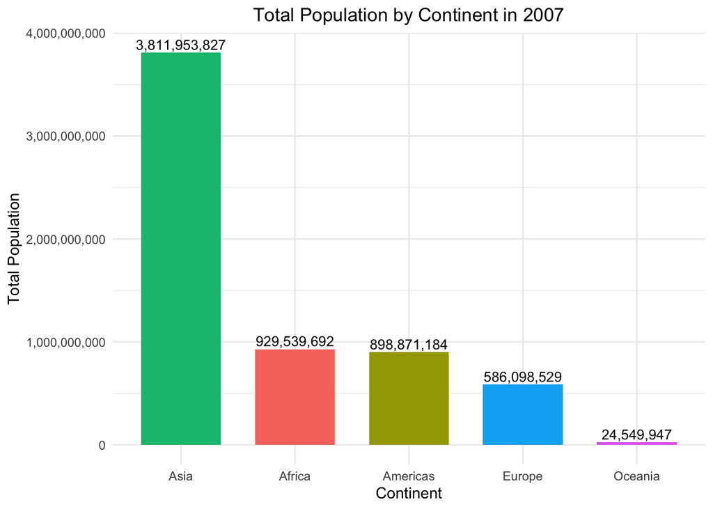

````markdown
```{r}
gapminder %>%
  filter(year == 2007) %>%
  group_by(continent) %>%
  summarise(total_population = sum(pop)) %>%
  ggplot(aes(x = fct_reorder(continent, total_population, .desc = TRUE),
             y = total_population,
             fill = continent)) +
  geom_col(show.legend = FALSE, width = 0.7) +
  geom_text(aes(label = scales::comma(total_population)),
            vjust = -0.3,
            size = 3.5) +
  labs(
    title = "Total Population by Continent in 2007",
    x = "Continent",
    y = "Total Population"
  ) +
  scale_y_continuous(labels = scales::comma) +
  theme_minimal() +
  theme(
    plot.title = element_text(hjust = 0.5)
  )
```
````

# 9 Q9. Shortening Factor Levels: top or bottom 5 lists

## 9.1 (1) Using the original gapminder data (not gapminder1), draw a chart that shows the total population by each Asian country in the year 2007, ordered by the size of the population in the chart. As usual, do this in one chain of codes and provide the necessary information and beautification to the chart to portray accurate communication to the viewers.

````markdown
```{r}
library(gapminder)
library(tidyverse)
library(patchwork)

# Filter gapminder for Asia in 2007 and count the number of countries
gapminder %>%
  filter(year == 2007, continent == "Asia") %>%
  summarise(number_of_countries = n())
```
````

| number_of_countries |
| --- |
| 33 |

There are 33 Asian countries in the filtered gapminder data for the year 2007.

````markdown
```{r}
# Print the filtered data to confirm the countries included
gapminder %>%
  filter(year == 2007, continent == "Asia")
```
````

| country | continent | year | lifeExp | pop | gdpPercap |
| --- | --- | --- | --- | --- | --- |
| Afghanistan | Asia | 2007 | 43.828 | 31889923 | 974.5803 |
| Bahrain | Asia | 2007 | 75.635 | 708573 | 29796.0483 |
| Bangladesh | Asia | 2007 | 64.062 | 150448339 | 1391.2538 |
| Cambodia | Asia | 2007 | 59.723 | 14131858 | 1713.7787 |
| China | Asia | 2007 | 72.961 | 1318683096 | 4959.1149 |
| Hong Kong, China | Asia | 2007 | 82.208 | 6980412 | 39724.9787 |
| India | Asia | 2007 | 64.698 | 1110396331 | 2452.2104 |
| Indonesia | Asia | 2007 | 70.650 | 223547000 | 3540.6516 |
| Iran | Asia | 2007 | 70.964 | 69453570 | 11605.7145 |
| Iraq | Asia | 2007 | 59.545 | 27499638 | 4471.0619 |

[output cut: 23 more lines]

## 9.3 Given the number of countries, it seems like a good idea to present the top 5 and bottom 5 countries, one at a time, and order the countries by life expectancy. Let’s first focus on the top 5 list. Do appropriate wrangling and visualization for the top 5 list.

The code below selects the top 5 Asian countries in 2007 based on life expectancy, orders the countries by life expectancy, and creates a presentable bar chart.

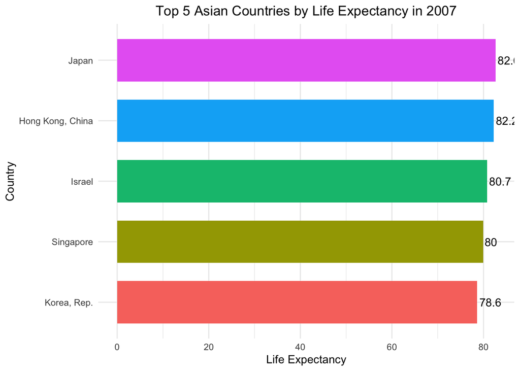

````markdown
```{r}
# Create the top 5 chart
top_5_asia <- gapminder %>%
  filter(year == 2007, continent == "Asia") %>%
  slice_max(order_by = lifeExp, n = 5) %>%
  mutate(country = fct_reorder(country, lifeExp))

top_5_plot <- ggplot(top_5_asia, aes(x = country, y = lifeExp, fill = country)) +
  geom_col(show.legend = FALSE, width = 0.7) +
  geom_text(aes(label = round(lifeExp, 1)), hjust = -0.1) +
  coord_flip() +
  labs(
    title = "Top 5 Asian Countries by Life Expectancy in 2007",
    x = "Country",
    y = "Life Expectancy"
  ) +
  theme_minimal() +
  theme(
    plot.title = element_text(hjust = 0.5)
  )

# Print the chart
top_5_plot
```
````

The code below creates a chart for the bottom 5 Asian countries by life expectancy in 2007, and then combines the top 5 and bottom 5 charts into one display using the patchwork package.

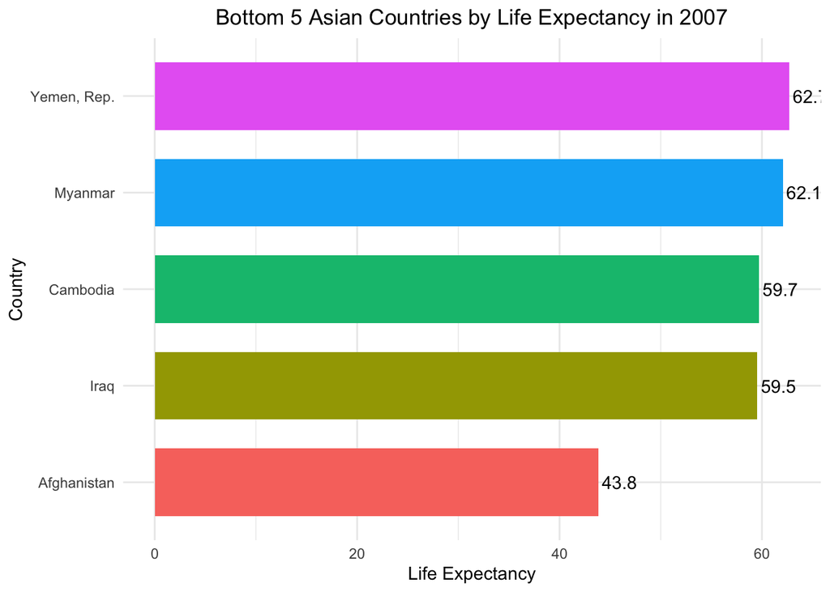

````markdown
```{r}
# Create the bottom 5 chart
bottom_5_asia <- gapminder %>%
  filter(year == 2007, continent == "Asia") %>%
  slice_min(order_by = lifeExp, n = 5) %>%
  mutate(country = fct_reorder(country, lifeExp))

bottom_5_plot <- ggplot(bottom_5_asia, aes(x = country, y = lifeExp, fill = country)) +
  geom_col(show.legend = FALSE, width = 0.7) +
  geom_text(aes(label = round(lifeExp, 1)), hjust = -0.1) +
  coord_flip() +
  labs(
    title = "Bottom 5 Asian Countries by Life Expectancy in 2007",
    x = "Country",
    y = "Life Expectancy"
  ) +
  theme_minimal() +
  theme(
    plot.title = element_text(hjust = 0.5)
  )

# Print the bottom 5 chart
bottom_5_plot
```
````

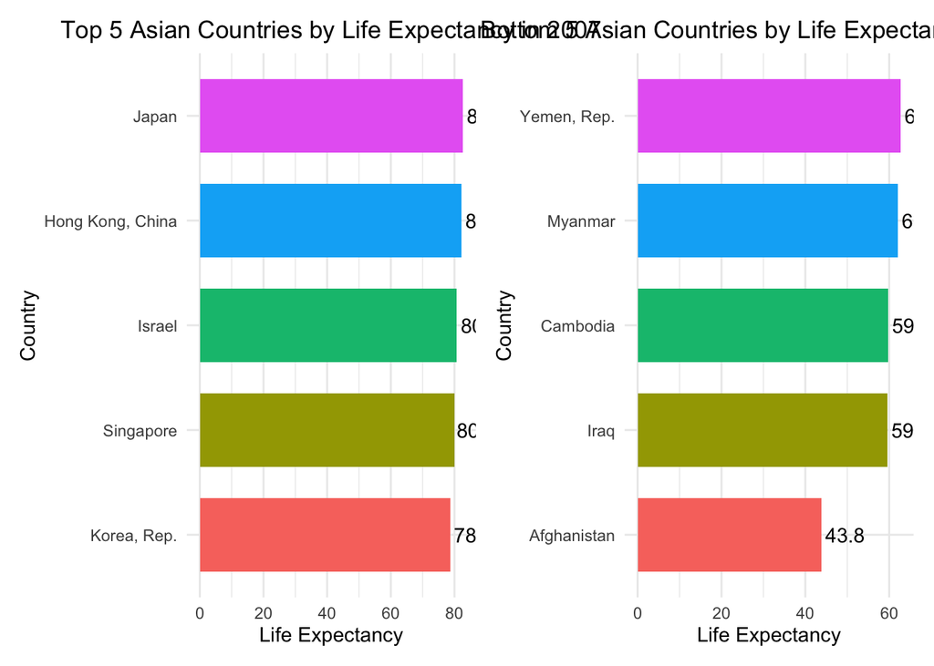

````markdown
```{r}
# Combine the two charts using patchwork
top_5_plot + bottom_5_plot
```
````

# 10 Date-time data type

## 10.1 Look up the help to understand the data and also run appropriate functions to understand the data.

````markdown
```{r}
# Install packages if needed
install.packages("nycflights13")
```
````

[output not shown]

````markdown
```{r}
install.packages("tidyverse")
```
````

[output not shown]

````markdown
```{r}
install.packages("lubridate")
```
````

[output not shown]

````markdown
```{r}
# Load packages
library(nycflights13)
library(tidyverse)
library(lubridate)

# Open the help file
?flights

# Examine the dataset
glimpse(flights)
head(flights)
summary(flights)
```
````

```
Rows: 336,776
Columns: 19
$ year           <int> 2013, 2013, 2013, 2013, 2013, 2013, 2013, 2013, 2013, 2…
$ month          <int> 1, 1, 1, 1, 1, 1, 1, 1, 1, 1, 1, 1, 1, 1, 1, 1, 1, 1, 1…
$ day            <int> 1, 1, 1, 1, 1, 1, 1, 1, 1, 1, 1, 1, 1, 1, 1, 1, 1, 1, 1…
$ dep_time       <int> 517, 533, 542, 544, 554, 554, 555, 557, 557, 558, 558, …
$ sched_dep_time <int> 515, 529, 540, 545, 600, 558, 600, 600, 600, 600, 600, …
$ dep_delay      <dbl> 2, 4, 2, -1, -6, -4, -5, -3, -3, -2, -2, -2, -2, -2, -1…
$ arr_time       <int> 830, 850, 923, 1004, 812, 740, 913, 709, 838, 753, 849,…
$ sched_arr_time <int> 819, 830, 850, 1022, 837, 728, 854, 723, 846, 745, 851,…
$ arr_delay      <dbl> 11, 20, 33, -18, -25, 12, 19, -14, -8, 8, -2, -3, 7, -1…
$ carrier        <chr> "UA", "UA", "AA", "B6", "DL", "UA", "B6", "EV", "B6", "…
$ flight         <int> 1545, 1714, 1141, 725, 461, 1696, 507, 5708, 79, 301, 4…
$ tailnum        <chr> "N14228", "N24211", "N619AA", "N804JB", "N668DN", "N394…
$ origin         <chr> "EWR", "LGA", "JFK", "JFK", "LGA", "EWR", "EWR", "LGA",…
$ dest           <chr> "IAH", "IAH", "MIA", "BQN", "ATL", "ORD", "FLL", "IAD",…
$ air_time       <dbl> 227, 227, 160, 183, 116, 150, 158, 53, 140, 138, 149, 1…
$ distance       <dbl> 1400, 1416, 1089, 1576, 762, 719, 1065, 229, 944, 733, …
$ hour           <dbl> 5, 5, 5, 5, 6, 5, 6, 6, 6, 6, 6, 6, 6, 6, 6, 5, 6, 6, 6…
$ minute         <dbl> 15, 29, 40, 45, 0, 58, 0, 0, 0, 0, 0, 0, 0, 0, 0, 59, 0…
$ time_hour      <dttm> 2013-01-01 05:00:00, 2013-01-01 05:00:00, 2013-01-01 0…
```

| year | month | day | dep_time | sched_dep_time | dep_delay | arr_time | sched_arr_time | arr_delay | carrier | flight | tailnum | origin | dest | air_time | distance | hour | minute | time_hour |
| --- | --- | --- | --- | --- | --- | --- | --- | --- | --- | --- | --- | --- | --- | --- | --- | --- | --- | --- |
| 2013 | 1 | 1 | 517 | 515 | 2 | 830 | 819 | 11 | UA | 1545 | N14228 | EWR | IAH | 227 | 1400 | 5 | 15 | 2013-01-01 05:00:00 |
| 2013 | 1 | 1 | 533 | 529 | 4 | 850 | 830 | 20 | UA | 1714 | N24211 | LGA | IAH | 227 | 1416 | 5 | 29 | 2013-01-01 05:00:00 |
| 2013 | 1 | 1 | 542 | 540 | 2 | 923 | 850 | 33 | AA | 1141 | N619AA | JFK | MIA | 160 | 1089 | 5 | 40 | 2013-01-01 05:00:00 |
| 2013 | 1 | 1 | 544 | 545 | -1 | 1004 | 1022 | -18 | B6 | 725 | N804JB | JFK | BQN | 183 | 1576 | 5 | 45 | 2013-01-01 05:00:00 |
| 2013 | 1 | 1 | 554 | 600 | -6 | 812 | 837 | -25 | DL | 461 | N668DN | LGA | ATL | 116 | 762 | 6 | 0 | 2013-01-01 06:00:00 |
| 2013 | 1 | 1 | 554 | 558 | -4 | 740 | 728 | 12 | UA | 1696 | N39463 | EWR | ORD | 150 | 719 | 5 | 58 | 2013-01-01 05:00:00 |

```
      year          month             day           dep_time    sched_dep_time
 Min.   :2013   Min.   : 1.000   Min.   : 1.00   Min.   :   1   Min.   : 106
 1st Qu.:2013   1st Qu.: 4.000   1st Qu.: 8.00   1st Qu.: 907   1st Qu.: 906
 Median :2013   Median : 7.000   Median :16.00   Median :1401   Median :1359
 Mean   :2013   Mean   : 6.549   Mean   :15.71   Mean   :1349   Mean   :1344
 3rd Qu.:2013   3rd Qu.:10.000   3rd Qu.:23.00   3rd Qu.:1744   3rd Qu.:1729
 Max.   :2013   Max.   :12.000   Max.   :31.00   Max.   :2400   Max.   :2359
                                                 NA's   :8255
   dep_delay          arr_time    sched_arr_time   arr_delay
 Min.   : -43.00   Min.   :   1   Min.   :   1   Min.   : -86.000
 1st Qu.:  -5.00   1st Qu.:1104   1st Qu.:1124   1st Qu.: -17.000
 Median :  -2.00   Median :1535   Median :1556   Median :  -5.000
 Mean   :  12.64   Mean   :1502   Mean   :1536   Mean   :   6.895
 3rd Qu.:  11.00   3rd Qu.:1940   3rd Qu.:1945   3rd Qu.:  14.000
 Max.   :1301.00   Max.   :2400   Max.   :2359   Max.   :1272.000
 NA's   :8255      NA's   :8713                  NA's   :9430
   carrier              flight       tailnum             origin
 Length:336776      Min.   :   1   Length:336776      Length:336776
 Class :character   1st Qu.: 553   Class :character   Class :character
 Mode  :character   Median :1496   Mode  :character   Mode  :character
                    Mean   :1972
                    3rd Qu.:3465
                    Max.   :8500

     dest              air_time        distance         hour
 Length:336776      Min.   : 20.0   Min.   :  17   Min.   : 1.00
 Class :character   1st Qu.: 82.0   1st Qu.: 502   1st Qu.: 9.00
 Mode  :character   Median :129.0   Median : 872   Median :13.00
                    Mean   :150.7   Mean   :1040   Mean   :13.18
                    3rd Qu.:192.0   3rd Qu.:1389   3rd Qu.:17.00
                    Max.   :695.0   Max.   :4983   Max.   :23.00
                    NA's   :9430
     minute        time_hour
 Min.   : 0.00   Min.   :2013-01-01 05:00:00
 1st Qu.: 8.00   1st Qu.:2013-04-04 13:00:00
 Median :29.00   Median :2013-07-03 10:00:00
 Mean   :26.23   Mean   :2013-07-03 05:22:54
 3rd Qu.:44.00   3rd Qu.:2013-10-01 07:00:00
 Max.   :59.00   Max.   :2013-12-31 23:00:00
```

## 10.2 Include only the records that do not have missing values in the following three variables: dep_time arr_time and air_time. Convert “dep_time” and “arr_time” to date-time data type, using “year”, “month”, and “day” as well as the hour and minutes information from “dep_time” and “arr_time”. Then select only some useful columns we will need to draw a chart since there are too many columns to display. Those variables are “origin”, “dest”, “air_time”, and any variables that start with ‘dep’ or ‘arr.’ Let’s save this subset of the data as “flights_lub.”

The code below removes rows with missing values in ‘dep_time’, ‘arr_time’, and ‘air_time’. Then it converts ‘dep_time’ and ‘arr_time’ into proper date-time variables by combining the date columns with the hour and minute values. After that, I keep only the requested columns and save the result as ‘flights_lub’.

````markdown
```{r}
# Create a cleaned subset called flights_lub
flights_lub <- flights %>%
  filter(!is.na(dep_time), !is.na(arr_time), !is.na(air_time)) %>%
  mutate(
    dep_time = sprintf("%04d", dep_time),
    arr_time = sprintf("%04d", arr_time),
    dep_time = make_datetime(
      year = year,
      month = month,
      day = day,
      hour = as.numeric(substr(dep_time, 1, 2)),
      min = as.numeric(substr(dep_time, 3, 4))
    ),
    arr_time = make_datetime(
      year = year,
      month = month,
      day = day,
      hour = as.numeric(substr(arr_time, 1, 2)),
      min = as.numeric(substr(arr_time, 3, 4))
    )
  ) %>%
  select(origin, dest, air_time, starts_with("dep"), starts_with("arr"))

# Print the data to confirm the wrangling worked
flights_lub
```
````

| origin | dest | air_time | dep_time | dep_delay | arr_time | arr_delay |
| --- | --- | --- | --- | --- | --- | --- |
| EWR | IAH | 227 | 2013-01-01 05:17:00 | 2 | 2013-01-01 08:30:00 | 11 |
| LGA | IAH | 227 | 2013-01-01 05:33:00 | 4 | 2013-01-01 08:50:00 | 20 |
| JFK | MIA | 160 | 2013-01-01 05:42:00 | 2 | 2013-01-01 09:23:00 | 33 |
| JFK | BQN | 183 | 2013-01-01 05:44:00 | -1 | 2013-01-01 10:04:00 | -18 |
| LGA | ATL | 116 | 2013-01-01 05:54:00 | -6 | 2013-01-01 08:12:00 | -25 |
| EWR | ORD | 150 | 2013-01-01 05:54:00 | -4 | 2013-01-01 07:40:00 | 12 |
| EWR | FLL | 158 | 2013-01-01 05:55:00 | -5 | 2013-01-01 09:13:00 | 19 |
| LGA | IAD | 53 | 2013-01-01 05:57:00 | -3 | 2013-01-01 07:09:00 | -14 |
| JFK | MCO | 140 | 2013-01-01 05:57:00 | -3 | 2013-01-01 08:38:00 | -8 |
| LGA | ORD | 138 | 2013-01-01 05:58:00 | -2 | 2013-01-01 07:53:00 | 8 |

[output cut: 9990 more lines]

## 10.3 Using the “dep_time” variable, display the frequency distribution of the count of flights departing from New York City over the entire year in 2013, from Jan. 1 to Dec. 31.

The chart below displays the frequency distribution of flight departures across the full year of 2013 using the dep_time variable.

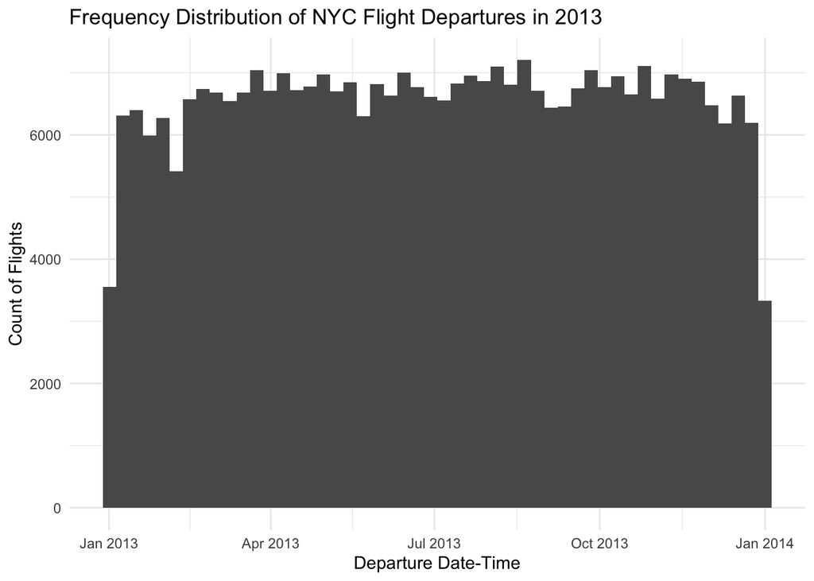

````markdown
```{r}
# Plot the frequency distribution of departures over the full year
ggplot(flights_lub, aes(x = dep_time)) +
  geom_histogram(bins = 50) +
  labs(
    title = "Frequency Distribution of NYC Flight Departures in 2013",
    x = "Departure Date-Time",
    y = "Count of Flights"
  ) +
  theme_minimal()
```
````

## 10.4 This time, let’s zoom in on just one day, the Fourth of July holiday. Display the frequency distribution of the flights departing from New York City during the entire day.

The chart below focuses only on flights departing on July 4, 2013, and shows the frequency distribution during that day.

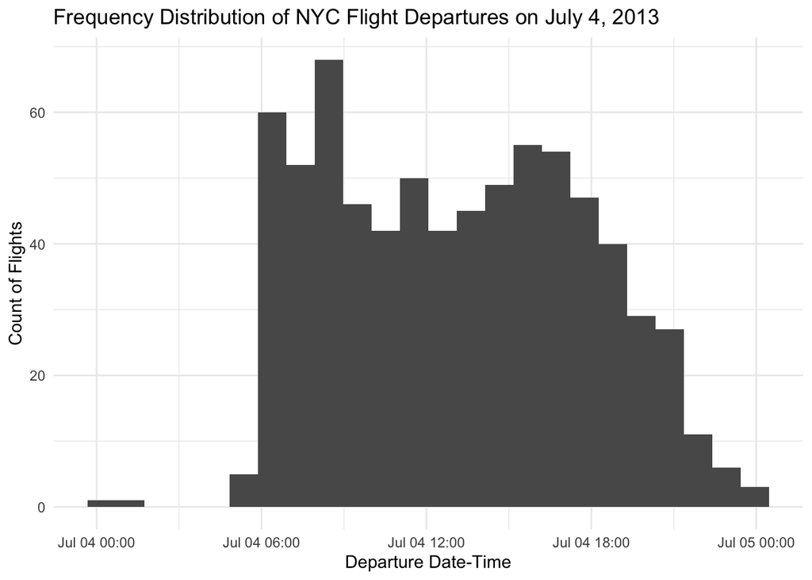

````markdown
```{r}
# Plot the frequency distribution of departures on July 4, 2013
flights_lub %>%
  filter(date(dep_time) == ymd("2013-07-04")) %>%
  ggplot(aes(x = dep_time)) +
  geom_histogram(bins = 24) +
  labs(
    title = "Frequency Distribution of NYC Flight Departures on July 4, 2013",
    x = "Departure Date-Time",
    y = "Count of Flights"
  ) +
  theme_minimal()
```
````

## 10.5 Using the “flights_lub” dataset, create the “travel_time” variable by subtracting “dep_time” from “arr_time”. Since arrival occurs later than departure, arr_time minus dep_time should be positive. Check this logic by sorting the data by the ascending order of “travel_time” Was the expectation met? No, because you will see negative minutes of travel_time. Pay attention to the type of data for travel_time. Why were there negative minutes?

The code below creates ‘travel_time’ by subtracting ‘dep_time’ from ‘arr_time’, then sorts the data from the smallest value to the largest value. This shows that some values are negative.

````markdown
```{r}
# Create travel_time and sort by ascending order
flights_lub <- flights_lub %>%
  mutate(travel_time = arr_time - dep_time)

# Print the smallest travel_time values
flights_lub %>%
  arrange(travel_time) %>%
  select(origin, dest, dep_time, arr_time, air_time, travel_time) %>%
  head(10)
```
````

| origin | dest | dep_time | arr_time | air_time | travel_time |
| --- | --- | --- | --- | --- | --- |
| EWR | BDL | 2013-06-12 23:38:00 | 2013-06-12 00:17:00 | 21 | -1401 mins |
| EWR | ALB | 2013-12-29 23:32:00 | 2013-12-29 00:14:00 | 26 | -1398 mins |
| EWR | ALB | 2013-11-06 23:35:00 | 2013-11-06 00:18:00 | 29 | -1397 mins |
| EWR | BWI | 2013-02-25 23:47:00 | 2013-02-25 00:30:00 | 33 | -1397 mins |
| EWR | BDL | 2013-08-13 23:51:00 | 2013-08-13 00:35:00 | 24 | -1396 mins |
| EWR | MDW | 2013-10-11 23:42:00 | 2013-10-11 00:27:00 | 92 | -1395 mins |
| EWR | ALB | 2013-02-26 23:56:00 | 2013-02-26 00:41:00 | 24 | -1395 mins |
| EWR | BWI | 2013-01-24 23:42:00 | 2013-01-24 00:28:00 | 33 | -1394 mins |
| EWR | PVD | 2013-12-23 23:33:00 | 2013-12-23 00:19:00 | 29 | -1394 mins |
| EWR | BWI | 2013-03-10 23:39:00 | 2013-03-10 00:25:00 | 34 | -1394 mins |

The expectation was not met because some ‘travel_time’ values are negative. The ‘travel_time’ variable is a time difference object. The negative values happen because some flights are overnight flights. In those cases, the arrival time is on the next day, but the initial ‘arr_time’ date was still assigned to the same day as departure.

## 10.6 That was because those flights were overnight flights. The original dep_time had only hour and minutes information before day information was added and the time of arrival is smaller than the time of departure for the overnight flights. Thus, we need to fix “arr_time” by adding one more day when there was such an overnight flight. Do the appropriate adjustment prior to the travel_time variable creation in the chain of codes connected through a series of pipe operators. Also, convert the travel_time to a numeric data type. Show that there are no negative minutes anymore.

````markdown
```{r}
# Fix overnight flights and recalculate travel_time in minutes
flights_lub <- flights %>%
  filter(!is.na(dep_time), !is.na(arr_time), !is.na(air_time)) %>%
  mutate(
    dep_time = sprintf("%04d", dep_time),
    arr_time = sprintf("%04d", arr_time),
    dep_time = make_datetime(
      year = year,
      month = month,
      day = day,
      hour = as.numeric(substr(dep_time, 1, 2)),
      min = as.numeric(substr(dep_time, 3, 4))
    ),
    arr_time = make_datetime(
      year = year,
      month = month,
      day = day,
      hour = as.numeric(substr(arr_time, 1, 2)),
      min = as.numeric(substr(arr_time, 3, 4))
    ),
    arr_time = if_else(arr_time < dep_time, arr_time + days(1), arr_time),
    travel_time = as.numeric(difftime(arr_time, dep_time, units = "mins"))
  ) %>%
  select(origin, dest, air_time, starts_with("dep"), starts_with("arr"), travel_time)

# Print the smallest travel_time values to confirm there are no negatives
flights_lub %>%
  arrange(travel_time) %>%
  select(origin, dest, dep_time, arr_time, air_time, travel_time) %>%
  head(10)
```
````

| origin | dest | dep_time | arr_time | air_time | travel_time |
| --- | --- | --- | --- | --- | --- |
| EWR | BDL | 2013-08-14 11:33:00 | 2013-08-14 12:06:00 | 23 | 33 |
| EWR | BDL | 2013-01-05 13:23:00 | 2013-01-05 13:58:00 | 23 | 35 |
| EWR | BDL | 2013-02-22 13:12:00 | 2013-02-22 13:47:00 | 23 | 35 |
| EWR | BDL | 2013-09-03 12:03:00 | 2013-09-03 12:38:00 | 21 | 35 |
| EWR | BDL | 2013-03-19 14:55:00 | 2013-03-19 15:31:00 | 22 | 36 |
| EWR | BDL | 2013-08-14 07:22:00 | 2013-08-14 07:58:00 | 22 | 36 |
| EWR | BDL | 2013-08-18 07:22:00 | 2013-08-18 07:58:00 | 22 | 36 |
| EWR | BDL | 2013-09-24 07:18:00 | 2013-09-24 07:54:00 | 24 | 36 |
| EWR | BDL | 2013-01-15 13:26:00 | 2013-01-15 14:03:00 | 22 | 37 |
| EWR | BDL | 2013-03-18 14:56:00 | 2013-03-18 15:33:00 | 21 | 37 |

## 10.7 Once again, zoom in on the Forth of July. How many flights departed from New York City on that day? Create a plot that shows the relationship between the “travel_time” and “air_time” What do you infer from it? Why is there not a perfect association?

The code below counts the flights on July 4, 2013, and then creates a scatterplot showing the relationship between ‘travel_time’ and ‘air_time’.

| number_of_flights |
| --- |
| 733 |

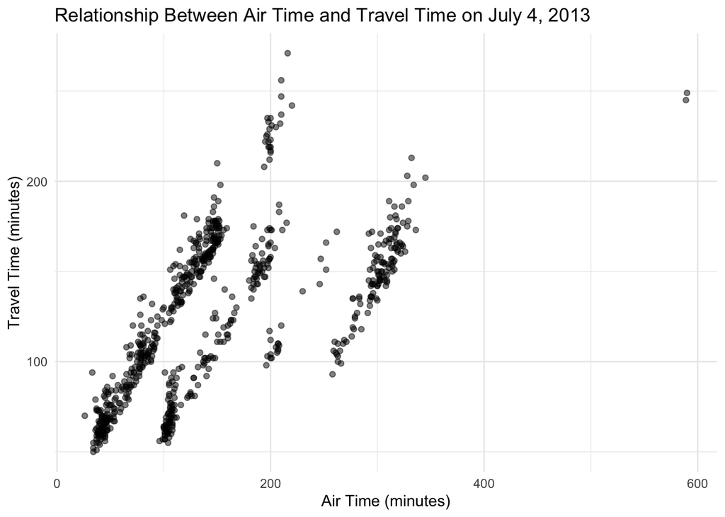

````markdown
```{r}
# Count flights on July 4, 2013
flights_lub %>%
  filter(date(dep_time) == ymd("2013-07-04")) %>%
  summarise(number_of_flights = n())
# Plot the relationship between travel_time and air_time for July 4, 2013
flights_lub %>%
  filter(date(dep_time) == ymd("2013-07-04")) %>%
  ggplot(aes(x = air_time, y = travel_time)) +
  geom_point(alpha = 0.5) +
  labs(
    title = "Relationship Between Air Time and Travel Time on July 4, 2013",
    x = "Air Time (minutes)",
    y = "Travel Time (minutes)"
  ) +
  theme_minimal()
```
````

The scatterplot shows a strong positive relationship between ‘air_time’ and ‘travel_time’. This makes sense because flights that spend more time in the air usually also have longer total travel time. However, the relationship is not perfect because travel_time includes more than just time in the air. It can also reflect taxi-out time, taxi-in time, and other delays before takeoff or after landing.